# The Lady Tasting Tea Example

Today in class we discussed the famous story of a lady who claimed that tea with milk tasted differently depending on whether the milk was added to the tea or the tea was added to the milk. The story is famous because of the setting in which she made this claim. She was attending a party in Cambridge, England, in the 1920s. Also in attendance were a number of university dons and their wives. The scientists in attendance scoffed at the woman and her claim. What, after all, could be the difference.

All the scientists but one, that is. Rather than simply dismiss the woman’s claim, R. A. Fisher proposed that they decide how one should test the claim. The tenor of the conversation changes at this suggestion, and the scientists began to discuss how the claim should be tested. Whithin a few minutes cups of tea with milk had been prepared and presented to the woman for tasting.

In class we decided to have the woman taste 10 cups of tea. To determine which was poured first into each cup we flipped a coin. We also thought about carefully measuring the amount of coffe and milk so that there were as few differences between the treatments as possible.

But to understand whether or not her number of correct identifications convinced us that she wasn’t guessing, we decided to compare her results with the results of a coin flip. We will call Heads correct guesses and Tails incorrect guesses.

For the randomization part of this course we will use functions that are built into a package called `mosaic’. When we want to use these tools we will need to load the package ‘mosaic’ (once) in the current R/Rstudio session before trying to run these functions.

```r
require(mosaic)
```

In class, we flipped an actual coin 10 times repeatedly to count the number of heads (successes). But this did not provide a lot of data and was very tedious. So now we will use R to do the coin flips for us.

To get a random flip of the coin we can use the command `rflip()`. Note that parentheses are used to define the input to function. In this case there is no input so the parentheses are empty but still very important to include as they signal to R that rflips is a function. Also note that R is case sensitive and the command will not work if we accidently type `Rflip()`.

```r
rflip()
```

```
##
## Flipping 1 coin [ Prob(Heads) = 0.5 ] ...
##
## T
##
## Number of Heads: 0 [Proportion Heads: 0]
```

`rflip` can also flip a number of coins for us by adjusting the function input. For example if we want to flip the coin 10 times we would type:

```r
rflip(10)
```

```
##
## Flipping 10 coins [ Prob(Heads) = 0.5 ] ...
##
## T H T T T H H H T H
##
## Number of Heads: 5 [Proportion Heads: 0.5]
```

Typing rflip a bunch of times is almost as tedius as flipping all of those coins for ourselves. But it is not too hard to tell R to do() this a bunch of times.

```r
do(3)*rflip(10)
```

```
##    n heads tails prop
## 1 10     7     3  0.7
## 2 10     7     3  0.7
## 3 10     5     5  0.5
```

```r
#store the results of 1000 simulated ladies
random.guessing <- do(1000) * rflip(10)
```

Looking at the table would be overwhelming, but we can look at a tally of the number correct guesses our random ladies made.

```r
tally(~heads,data=random.guessing)
```

```
## heads
##   1   2   3   4   5   6   7   8   9  10
##   9  45 115 237 239 188 119  38   8   2
```

We could also display percentages if you would like by adjusting the format options for the tally function.

```r
tally(~heads, data=random.guessing, format="prop")
```

```
## heads
##     1     2     3     4     5     6     7     8     9    10
## 0.009 0.045 0.115 0.237 0.239 0.188 0.119 0.038 0.008 0.002
```

We can also look at the results from our random lady simulations as a histogram

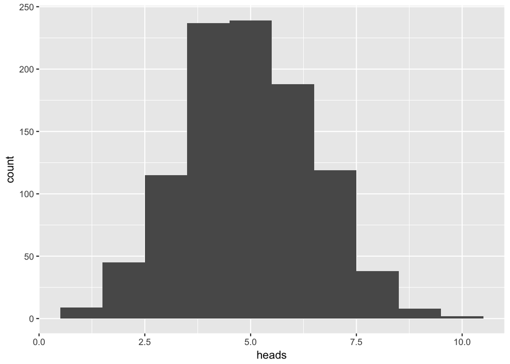

```r
ggplot(data=random.guessing, aes(x=heads))+geom_histogram(,binwidth=1)
```

You might be surprised to see that only 25% of the random ladies guessed half of the 10 cups correctly (5 correct), but most of the ladies were correct on 4, 5, or 6 cups. In fact about 90% of the results are between 3 and 7 (inclusive). But getting 8 correct is a bit unusual and 9 or 10 correct is even more unusual.

**A different experimental design** Suppose that we instead decided to prepare five cups each way (and that the woman tasting knows this). We give her five cards labeled “milk first” and she must place them next to the cups that had milk poured in them first. How does this design change things?

In class we discussed how we could set up a simulation that would tell us what to expect if the woman were guessing randomly. We decided that we could simulate this by shuffling a deck of 10 cards, dealing five of them, and counting the red cards as correct guesses.

To do this in R, we setup a vector that stores whether the cup is milk-first (M) or tea-first (T).

```r
cards <- factor(c("M","M","M","M","M","T","T","T","T","T"))
```

We then deal 5 cards from the ten we setup above and tally the number of `M's and`T’s is the sample.

```r
tally(~deal(cards,5))
```

```
## deal(cards, 5)
## M T
## 4 1
```

And we can repeat this 1,000 times.

```r
results <- do(1000) * tally(~deal(cards,5))
```

And take a tally of the number of times we see each possible number of correctly placed “milk first” cards.

```r
tally(~M,data=results)
```

```
## M
##   0   1   2   3   4   5
##   4 118 383 398  93   4
```

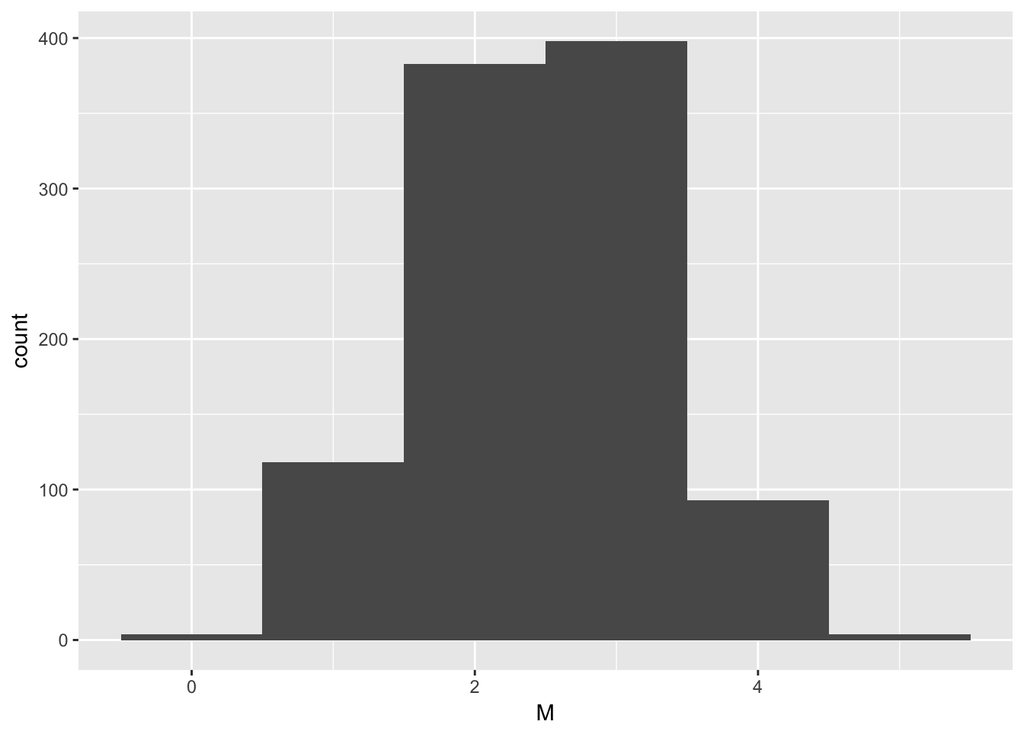

```r
ggplot(data=results, aes(x=M))+geom_histogram(,binwidth=1)
```

We can look at the proportions instead of the counts

```r
tally(~M,data=results, format="prop")
```

```
## M
##     0     1     2     3     4     5
## 0.004 0.118 0.383 0.398 0.093 0.004
```

We can also look at the percentages

```r
tally(~M,data=results, format="perc")
```

```
## M
##    0    1    2    3    4    5
##  0.4 11.8 38.3 39.8  9.3  0.4
```

In this case she would probably have to get all 5 cards placed correctly to convince us that she was not randomly guessing. How you design the study makes a difference in how good your results are.

We will use a randomization approach throughout the rest of the semester before moving into other statistical tests. Whenever you see a problem you should ask yourself “How likely is this result by random chance?” We will develop a selection of different randomization approaches, but your goal is always to simulate what you would expect to happen if everything was random and then look at how rare (or common) your data is.

# Examples from our book

## Gender and job promotion

For the gender and promotion study on page 62, the null hypothesis was that there was no discrimination in promotion and that the differences seen are solely because the individuals who did not think that the candidate was promotable happened to get more of the files with a female name on the file (and they would have rejected the file no matter what the name on the file was). So to simulate the null hypothesis, we will make 24 cards labeled male, and 24 cards labeled female and deal 35 to the supervisors who will promote the applicant, and 13 to the supervisors who will not promote. Here, typing out “female” 24 times would be onerous, so we will use the function `rep()` which will do the repetitive part for us.

```r
cards <- factor(c(rep("female",24),rep("male",24)))
```

Here we will deal just 35 of the cards for promotion. If we see $k$ women getting promoted, then we know that $24-k$ of them did not get promoted. So we don’t really need to look at the second pile of the remaining 13 cards.

```r
tally(~deal(cards,35))
```

```
## deal(cards, 35)
## female   male
##     19     16
```

And we can repeat this 10,000 times.

```r
results <- do(10000) * tally(~deal(cards,35))
head(results)
```

```
##   female male
## 1     17   18
## 2     16   19
## 3     16   19
## 4     16   19
## 5     18   17
## 6     18   17
```

```r
results <- results %>%
  mutate(p_female = female/75) %>%
  mutate(p_male = male/75) %>%
  mutate(difference = p_male - p_female)
```

Now we can tally these differences:

```r
tally(~difference,data=results, format="prop")
```

```
## difference
##  -0.146666666666667               -0.12 -0.0933333333333334
##              0.0005              0.0035              0.0183
## -0.0666666666666667               -0.04 -0.0133333333333333
##              0.0726              0.1653              0.2458
##  0.0133333333333333                0.04  0.0666666666666667
##              0.2389              0.1613              0.0692
##  0.0933333333333334                0.12
##              0.0205              0.0041
```

That is a bit of a mess, maybe it will be clearer as a histogram.

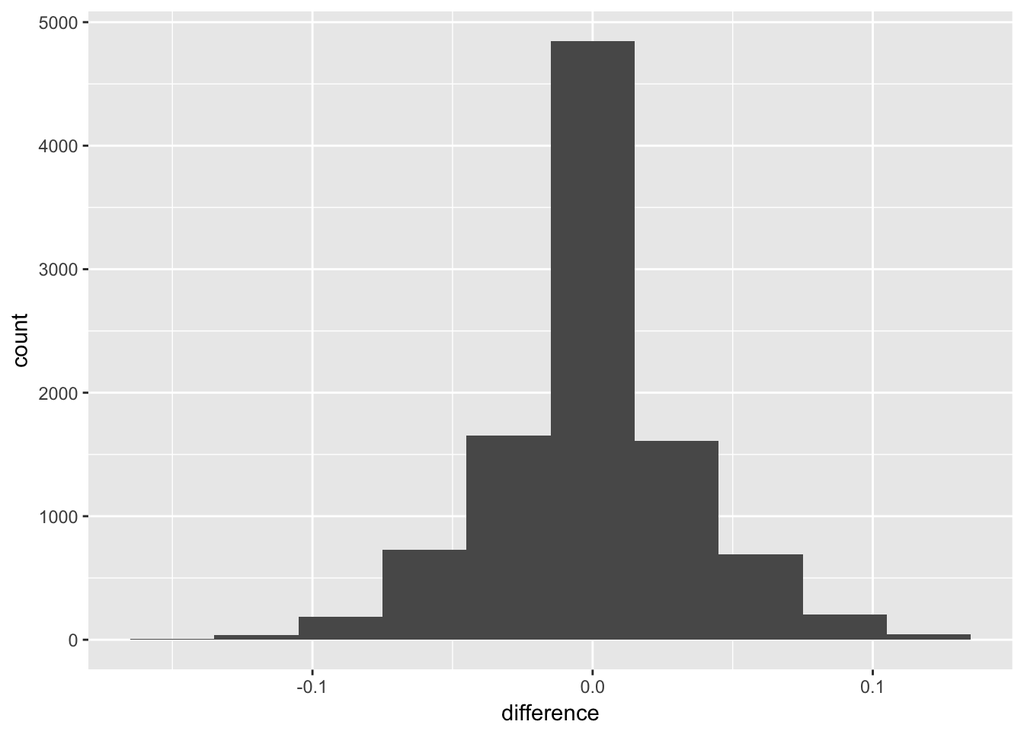

```r
ggplot(data=results, aes(x=difference))+geom_histogram(,binwidth=.03)
```

That helps, but what we would really like to do is count how frequently the difference is at least 29.2% or 0.292 and then figure out the fraction of simulation runs that had a difference of at least 29.2%.

```r
summary <- results %>%
  filter(difference >= 0.292) %>%
  summarize(count = n())
summary$count/length(results$difference)
```

```
## [1] 0
```

This means that if there were no treatment effect, then we would observe a difference this large around (the number above) of the time. (Note: The exact number will change each time the simulation is run.)

## Purchasing habits based on messages about saving

For the expirment described in section 2.2.1, the null hypothesis was that there would be no difference in the spending behavior of students between the two groups. This assumes that students in each group are equally likely to buy the CD and the fact that we see a larger fraction buying the CD in the control group is because we happened to put more students who are inclined to buy the CD into the control group (and not because students in the treatment group are less likely to buy the CD). To simulate this, we can create 75 “treatment” cards and 75 “control” cards and deal them into a pile of 97 who buy the DVD and 53 who don’t buy the DVD. We will actually just deal 53 for the ones who don’t buy the DVD (“successes”) because we know that the rest of the control and treatment groups will buy the DVD.

```r
cards <- factor(c(rep("treatment",75),rep("control",75)))
results <- do(10000) * tally(~deal(cards,53))
head(results)
```

```
##   control treatment
## 1      29        24
## 2      26        27
## 3      30        23
## 4      26        27
## 5      26        27
## 6      30        23
```

New we will use those results to compute the difference in the fractions of control and treatment promoted for the completely random trials.

```r
results <- results %>%
  mutate(p_control = control/75) %>%
  mutate(p_treatment = treatment/75) %>%
  mutate(difference = p_treatment - p_control)
```

Now we can tally these differences:

```r
tally(~difference,data=results, format="prop")
```

```
## difference
##               -0.28  -0.253333333333333  -0.226666666666667
##              0.0002              0.0003              0.0014
##                -0.2  -0.173333333333333  -0.146666666666667
##              0.0058              0.0114              0.0226
##               -0.12 -0.0933333333333334 -0.0666666666666667
##              0.0384              0.0679              0.1009
##               -0.04 -0.0133333333333333  0.0133333333333333
##              0.1177              0.1345              0.1357
##                0.04  0.0666666666666667  0.0933333333333334
##              0.1198              0.0951              0.0674
##                0.12   0.146666666666667   0.173333333333333
##              0.0398              0.0202              0.0122
##                 0.2   0.226666666666667   0.253333333333333
##              0.0046              0.0027              0.0011
##                0.28
##              0.0003
```

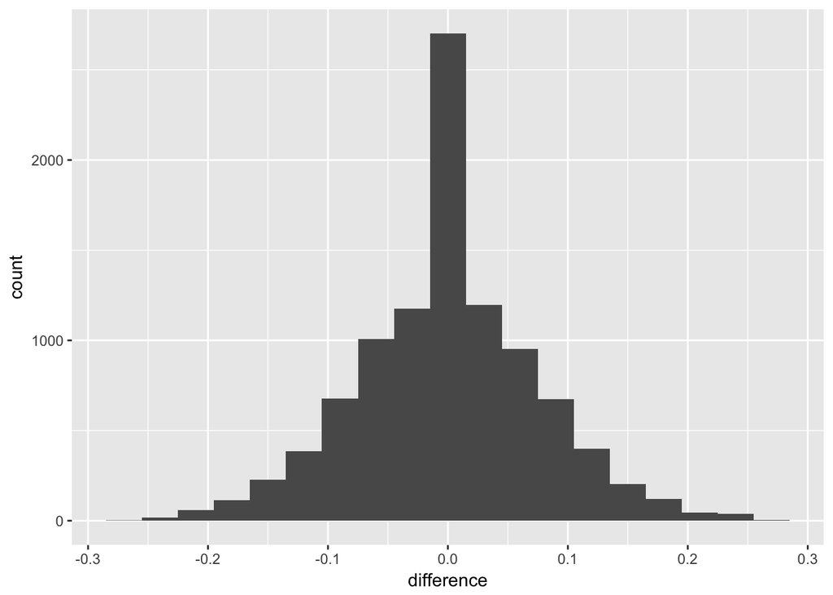

```r
ggplot(data=results, aes(x=difference))+geom_histogram(,binwidth=.03)
```

What we would really like to do is count how frequently the difference is at least 0.2.

```r
summary <- results %>%
  filter(difference >= 0.2) %>%
  summarize(count = n())
summary$count/length(results$difference)
```

```
## [1] 0.0041
```